# Sociodemographic Characteristics

## Residence in the Default World, Language, Political Perspectives, and Spiritual Perspectives

## Region of Residence

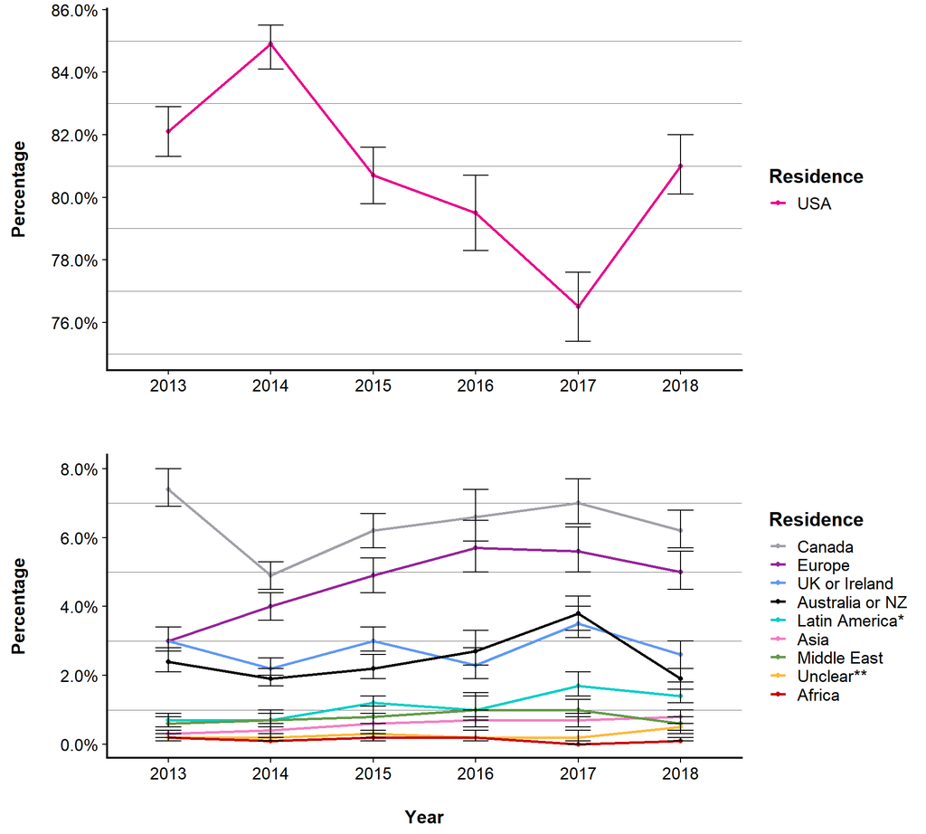

Error bars indicate the upper and lower bounds of the 95% confidence intervals.

* "Latin America" includes Central and South America, the Caribbeans, and countries of North America that are south of the USA.  
** "Unclear" denotes respondents who selected the "Other" option, but either did not provide a detailed response or whose detailed response could not be interpreted.

|  | 2013 Percent | 2013 MoE +/- % |  | 2014 Percent | 2014 MoE +/- % |  | 2015 Percent | 2015 MoE +/- % |  | 2016 Percent | 2016 MoE +/- % |  | 2017 Percent | 2017 MoE +/- % |  | 2018 Percent | 2018 MoE +/- % |
| --- | --- | --- | --- | --- | --- | --- | --- | --- | --- | --- | --- | --- | --- | --- | --- | --- | --- |
| USA | 82.1 | 0.8 |  | 84.9 | 0.8 |  | 80.7 | 1.0 |  | 79.5 | 1.2 |  | 76.5 | 1.0 |  | 81.0 | 1.0 |
| Canada | 7.4 | 0.6 |  | 4.9 | 0.4 |  | 6.2 | 0.6 |  | 6.6 | 0.8 |  | 7.0 | 0.6 |  | 6.2 | 0.6 |
| Europe | 3.0 | 0.4 |  | 4.0 | 0.4 |  | 4.9 | 0.6 |  | 5.7 | 0.8 |  | 5.6 | 0.6 |  | 5.0 | 0.6 |
| UK or Ireland | 3.0 | 0.4 |  | 2.2 | 0.2 |  | 3.0 | 0.4 |  | 2.3 | 0.4 |  | 3.5 | 0.4 |  | 2.6 | 0.4 |
| Australia or NZ | 2.4 | 0.4 |  | 1.9 | 0.2 |  | 2.2 | 0.4 |  | 2.7 | 0.6 |  | 3.8 | 0.4 |  | 1.9 | 0.4 |
| Latin America* | 0.7 | 0.2 |  | 0.7 | 0.2 |  | 1.2 | 0.2 |  | 1.0 | 0.4 |  | 1.7 | 0.4 |  | 1.4 | 0.4 |
| Asia | 0.3 | 0.2 |  | 0.4 | 0.2 |  | 0.6 | 0.2 |  | 0.7 | 0.2 |  | 0.7 | 0.2 |  | 0.8 | 0.2 |
| Middle East | 0.6 | 0.2 |  | 0.7 | 0.2 |  | 0.8 | 0.2 |  | 1.0 | 0.4 |  | 1.0 | 0.2 |  | 0.6 | 0.2 |
| Unclear** | 0.2 | 0.0 |  | 0.2 | 0.2 |  | 0.3 | 0.2 |  | 0.2 | 0.2 |  | 0.2 | 0.2 |  | 0.5 | 0.2 |
| Africa | 0.2 | 0.2 |  | 0.1 | 0.0 |  | 0.2 | 0.0 |  | 0.2 | 0.2 |  | 0.0 | 0.0 |  | 0.1 | 0.0 |

## State of Residence (US Residents Only)*

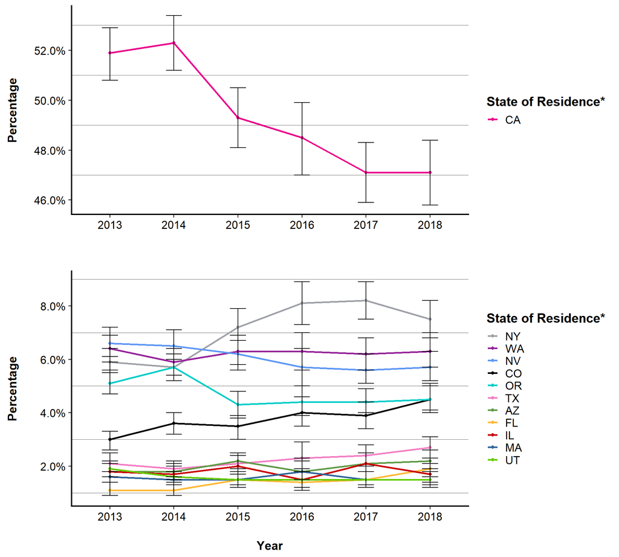

Error bars indicate the upper and lower bounds of the 95% confidence intervals.

* The plot above and table below display data for any state of residence reported by 1.5% or more or the 2018 BRC population who reported residing in the US.

|  | 2013 Percent | 2013 MoE +/- % |  | 2014 Percent | 2014 MoE +/- % |  | 2015 Percent | 2015 MoE +/- % |  | 2016 Percent | 2016 MoE +/- % |  | 2017 Percent | 2017 MoE +/- % |  | 2018 Percent | 2018 MoE +/- % |
| --- | --- | --- | --- | --- | --- | --- | --- | --- | --- | --- | --- | --- | --- | --- | --- | --- | --- |
| CA | 51.9 | 1.1 |  | 52.3 | 1.1 |  | 49.3 | 1.2 |  | 48.5 | 1.5 |  | 47.1 | 1.2 |  | 47.1 | 1.2 |
| NY | 5.9 | 0.5 |  | 5.7 | 0.5 |  | 7.2 | 0.6 |  | 8.1 | 0.8 |  | 8.2 | 0.8 |  | 7.5 | 0.8 |
| WA | 6.4 | 0.5 |  | 5.9 | 0.5 |  | 6.3 | 0.6 |  | 6.3 | 0.7 |  | 6.2 | 0.6 |  | 6.3 | 0.6 |
| NV | 6.6 | 0.6 |  | 6.5 | 0.6 |  | 6.2 | 0.6 |  | 5.7 | 0.7 |  | 5.6 | 0.6 |  | 5.7 | 0.6 |
| CO | 3.0 | 0.4 |  | 3.6 | 0.4 |  | 3.5 | 0.5 |  | 4.0 | 0.6 |  | 3.9 | 0.4 |  | 4.5 | 0.6 |
| OR | 5.1 | 0.5 |  | 5.7 | 0.5 |  | 4.3 | 0.5 |  | 4.4 | 0.6 |  | 4.4 | 0.4 |  | 4.5 | 0.6 |
| TX | 2.1 | 0.3 |  | 1.9 | 0.3 |  | 2.1 | 0.4 |  | 2.3 | 0.5 |  | 2.4 | 0.4 |  | 2.7 | 0.4 |
| AZ | 1.8 | 0.3 |  | 1.8 | 0.3 |  | 2.2 | 0.4 |  | 1.8 | 0.4 |  | 2.1 | 0.4 |  | 2.2 | 0.4 |
| FL | 1.1 | 0.3 |  | 1.1 | 0.2 |  | 1.5 | 0.3 |  | 1.4 | 0.4 |  | 1.5 | 0.4 |  | 1.9 | 0.4 |
| IL | 1.8 | 0.3 |  | 1.7 | 0.3 |  | 2.0 | 0.4 |  | 1.5 | 0.4 |  | 2.1 | 0.4 |  | 1.7 | 0.4 |
| UT | 1.9 | 0.3 |  | 1.6 | 0.3 |  | 1.5 | 0.3 |  | 1.5 | 0.4 |  | 1.5 | 0.2 |  | 1.5 | 0.2 |
| MA | 1.6 | 0.3 |  | 1.5 | 0.3 |  | 1.5 | 0.3 |  | 1.8 | 0.4 |  | 1.5 | 0.4 |  | 1.5 | 0.4 |

## Native Language*

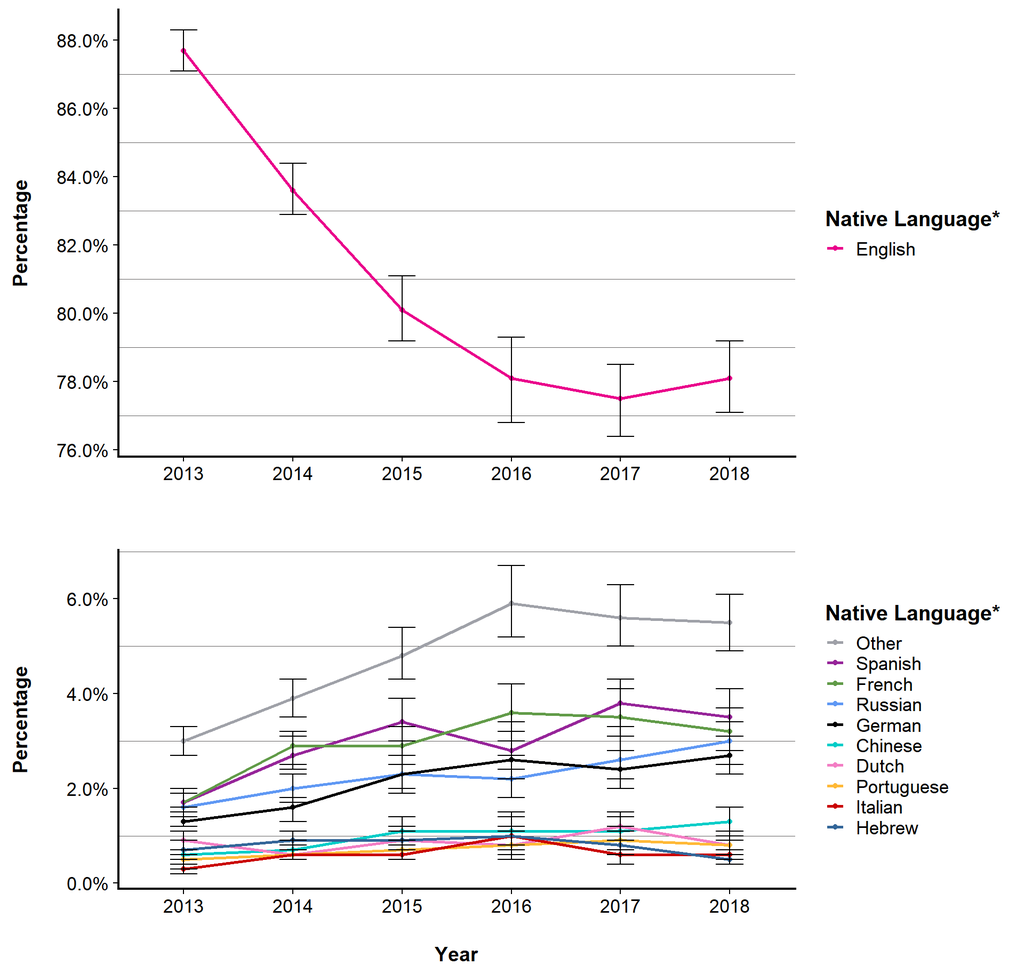

Error bars indicate the upper and lower bounds of the 95% confidence intervals.

* "Native language" was defined in the online survey as the first language learned and still used. The plot above and table below include data for any language reported by 1.0% or more of BRC residents in at least one year from 2013-18, with one exception: Portuguese has not ever represented 1.0% or more of the BRC population, but in 2018 the proportion of native Portuguese speakers rose above or equal to the proportion of several other languages that have made up more than 1.0% of the BRC population in past years.

|  | 2013 Percent | 2013 MoE +/- % |  | 2014 Percent | 2014 MoE +/- % |  | 2015 Percent | 2015 MoE +/- % |  | 2016 Percent | 2016 MoE +/- % |  | 2017 Percent | 2017 MoE +/- % |  | 2018 Percent | 2018 MoE +/- % |
| --- | --- | --- | --- | --- | --- | --- | --- | --- | --- | --- | --- | --- | --- | --- | --- | --- | --- |
| English | 87.7 | 0.6 |  | 83.6 | 0.8 |  | 80.1 | 1.0 |  | 78.1 | 1.2 |  | 77.5 | 1.0 |  | 78.1 | 1.0 |
| Other | 3.0 | 0.4 |  | 3.9 | 0.4 |  | 4.8 | 0.6 |  | 5.9 | 0.8 |  | 5.6 | 0.6 |  | 5.5 | 0.6 |
| Spanish | 1.7 | 0.2 |  | 2.7 | 0.4 |  | 3.4 | 0.4 |  | 2.8 | 0.6 |  | 3.8 | 0.6 |  | 3.5 | 0.4 |
| French | 1.7 | 0.2 |  | 2.9 | 0.4 |  | 2.9 | 0.4 |  | 3.6 | 0.6 |  | 3.5 | 0.6 |  | 3.2 | 0.4 |
| Russian | 1.6 | 0.2 |  | 2.0 | 0.4 |  | 2.3 | 0.4 |  | 2.2 | 0.4 |  | 2.6 | 0.4 |  | 3.0 | 0.4 |
| German | 1.3 | 0.2 |  | 1.6 | 0.2 |  | 2.3 | 0.4 |  | 2.6 | 0.6 |  | 2.4 | 0.4 |  | 2.7 | 0.4 |
| Chinese | 0.6 | 0.2 |  | 0.7 | 0.2 |  | 1.1 | 0.2 |  | 1.1 | 0.4 |  | 1.1 | 0.2 |  | 1.3 | 0.4 |
| Dutch | 0.9 | 0.2 |  | 0.6 | 0.2 |  | 0.9 | 0.2 |  | 0.8 | 0.2 |  | 1.2 | 0.2 |  | 0.8 | 0.2 |
| Portuguese | 0.5 | 0.2 |  | 0.6 | 0.2 |  | 0.7 | 0.2 |  | 0.8 | 0.2 |  | 0.9 | 0.2 |  | 0.8 | 0.2 |
| Italian | 0.3 | 0.2 |  | 0.6 | 0.2 |  | 0.6 | 0.2 |  | 1.0 | 0.4 |  | 0.6 | 0.2 |  | 0.6 | 0.2 |
| Hebrew | 0.7 | 0.2 |  | 0.9 | 0.2 |  | 0.9 | 0.2 |  | 1.0 | 0.4 |  | 0.8 | 0.2 |  | 0.5 | 0.2 |

## Politics

### Primary Political Self-Identity

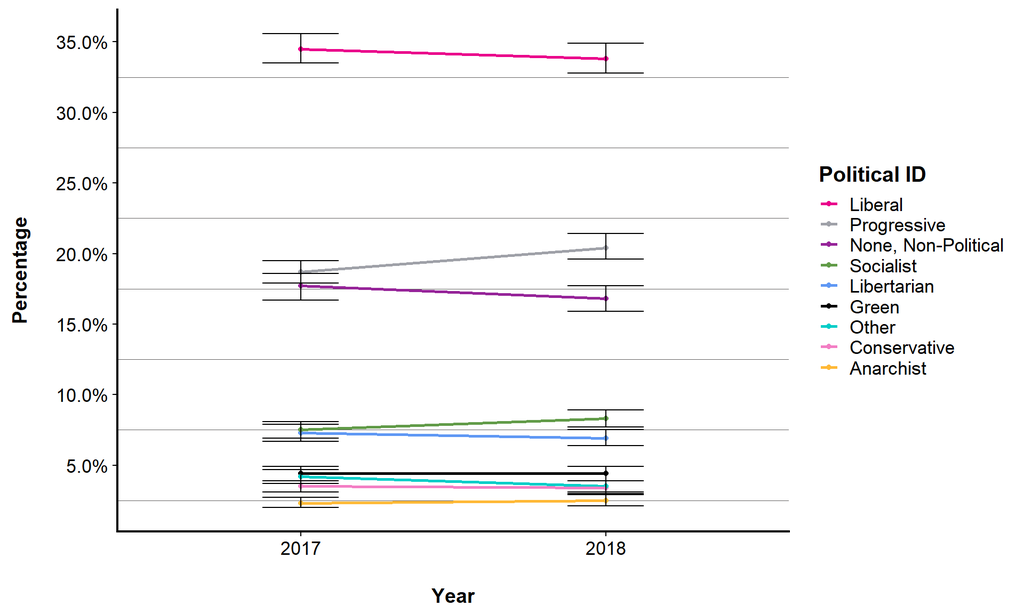

Error bars indicate the upper and lower bounds of the 95% confidence intervals.

|  | 2017 Percent | 2017 MoE +/- % |  | 2018 Percent | 2018 MoE +/- % |
| --- | --- | --- | --- | --- | --- |
| Liberal | 34.5 | 1.0 |  | 33.8 | 1.0 |
| Progressive | 18.7 | 0.8 |  | 20.4 | 1.0 |
| None, Non-Political | 17.7 | 1.0 |  | 16.8 | 1.0 |
| Socialist | 7.5 | 0.6 |  | 8.3 | 0.6 |
| Libertarian | 7.3 | 0.6 |  | 6.9 | 0.6 |
| Green | 4.4 | 0.6 |  | 4.4 | 0.6 |
| Other | 4.2 | 0.4 |  | 3.5 | 0.4 |
| Conservative | 3.5 | 0.4 |  | 3.4 | 0.4 |
| Anarchist | 2.3 | 0.4 |  | 2.5 | 0.4 |

## Politics

### US Political Party*

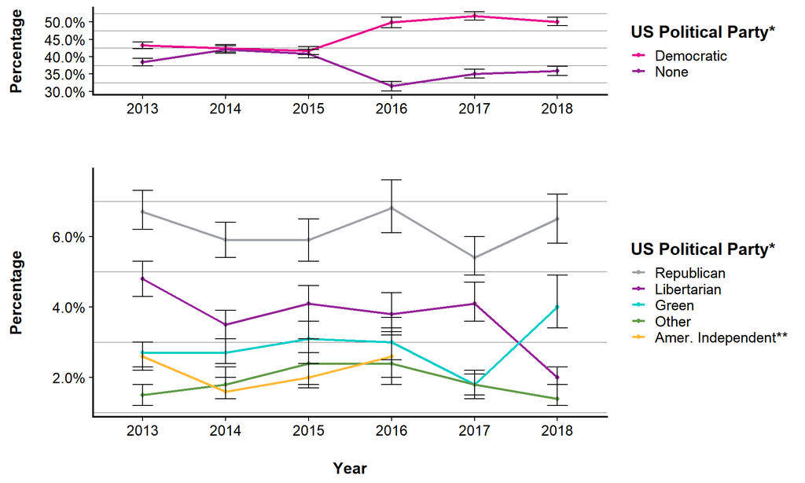

Error bars indicate the upper and lower bounds of the 95% confidence intervals.

* The plot above and table below represent BRC residents who indicated eligibility to vote in the US and selected one of the available answers. It excludes participants who indicated ineligibility to vote, or who indicated eligibility but declined to provide their party affiliation.  
** "American Independent Party (formerly America's Party)" was provided as an option in the 2013-16 online surveys but was removed from the online survey in 2017. This may have impacted the proportion of other responses in 2017-18.

|  | 2013 Percent | 2013 MoE +/- % |  | 2014 Percent | 2014 MoE +/- % |  | 2015 Percent | 2015 MoE +/- % |  | 2016 Percent | 2016 MoE +/- % |  | 2017 Percent | 2017 MoE +/- % |  | 2018 Percent | 2018 MoE +/- % |
| --- | --- | --- | --- | --- | --- | --- | --- | --- | --- | --- | --- | --- | --- | --- | --- | --- | --- |
| Democratic | 43.3 | 1.0 |  | 42.4 | 1.2 |  | 41.7 | 1.2 |  | 49.9 | 1.6 |  | 51.7 | 1.2 |  | 50.1 | 1.4 |
| None | 38.4 | 1.0 |  | 42.1 | 1.2 |  | 40.9 | 1.2 |  | 31.5 | 1.4 |  | 35.1 | 1.2 |  | 35.9 | 1.2 |
| Republican | 6.7 | 0.6 |  | 5.9 | 0.6 |  | 5.9 | 0.6 |  | 6.8 | 0.8 |  | 5.4 | 0.6 |  | 6.5 | 0.6 |
| Libertarian | 4.8 | 0.6 |  | 3.5 | 0.4 |  | 4.1 | 0.6 |  | 3.8 | 0.6 |  | 4.1 | 0.6 |  | 2.0 | 0.2 |
| Green | 2.7 | 0.4 |  | 2.7 | 0.4 |  | 3.1 | 0.4 |  | 3.0 | 0.6 |  | 1.8 | 0.2 |  | 4.0 | 0.8 |
| Amer. Independent** | 2.6 | 0.4 |  | 1.6 | 0.4 |  | 2.0 | 0.4 |  | 2.6 | 0.6 |  | NA | NA |  | NA | NA |
| Other | 1.5 | 0.4 |  | 1.8 | 0.4 |  | 2.4 | 0.6 |  | 2.4 | 0.8 |  | 1.8 | 0.4 |  | 1.4 | 0.4 |

## Politics

### US Voting History*

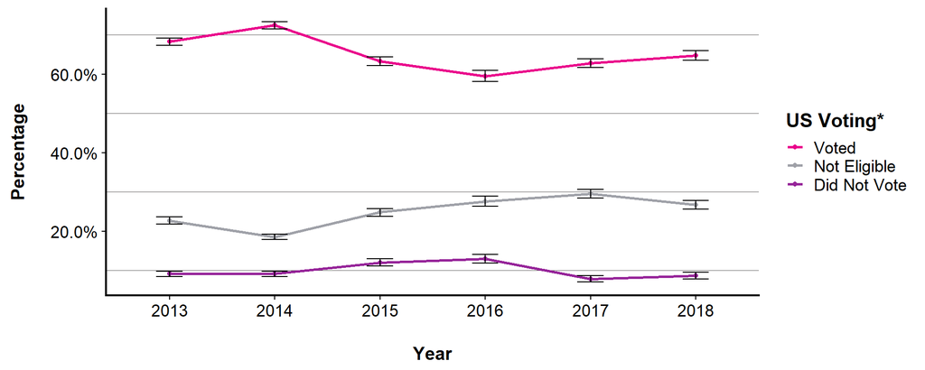

Error bars indicate the upper and lower bounds of the 95% confidence intervals.

* Eligible voters in the "Voted" population indicated voting in 1+ US federal elections over the four years prior to the year of the survey. Eligible participants in the "Did Not Vote" population indicated voting in no US federal elections over the same time period.

|  | 2013 Percent | 2013 MoE +/- % |  | 2014 Percent | 2014 MoE +/- % |  | 2015 Percent | 2015 MoE +/- % |  | 2016 Percent | 2016 MoE +/- % |  | 2017 Percent | 2017 MoE +/- % |  | 2018 Percent | 2018 MoE +/- % |
| --- | --- | --- | --- | --- | --- | --- | --- | --- | --- | --- | --- | --- | --- | --- | --- | --- | --- |
| Voted | 68.3 | 1.0 |  | 72.4 | 1.0 |  | 63.2 | 1.2 |  | 59.5 | 1.4 |  | 62.8 | 1.2 |  | 64.7 | 1.2 |
| Not Eligible | 22.7 | 1.0 |  | 18.5 | 0.8 |  | 24.8 | 1.0 |  | 27.6 | 1.4 |  | 29.5 | 1.2 |  | 26.7 | 1.2 |
| Did Not Vote | 9.1 | 0.8 |  | 9.1 | 0.6 |  | 12.0 | 0.8 |  | 13.0 | 1.2 |  | 7.8 | 0.8 |  | 8.6 | 0.8 |

## Spiritual Perspectives

### Spirituality

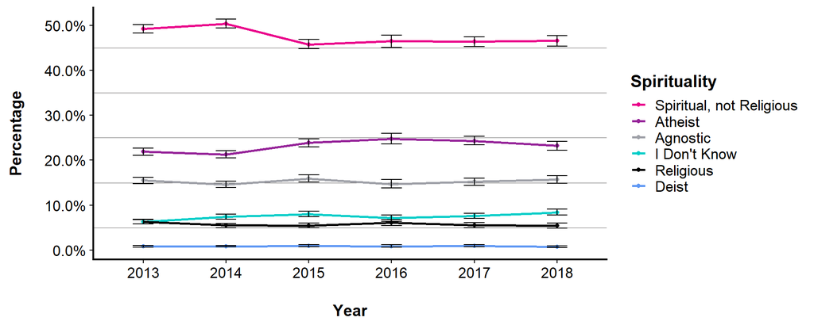

Error bars indicate the upper and lower bounds of the 95% confidence intervals.

|  | 2013 Percent | 2013 MoE +/- % |  | 2014 Percent | 2014 MoE +/- % |  | 2015 Percent | 2015 MoE +/- % |  | 2016 Percent | 2016 MoE +/- % |  | 2017 Percent | 2017 MoE +/- % |  | 2018 Percent | 2018 MoE +/- % |
| --- | --- | --- | --- | --- | --- | --- | --- | --- | --- | --- | --- | --- | --- | --- | --- | --- | --- |
| Spiritual, not Religious | 49.2 | 1.0 |  | 50.4 | 1.0 |  | 45.8 | 1.0 |  | 46.5 | 1.4 |  | 46.4 | 1.2 |  | 46.6 | 1.2 |
| Atheist | 21.9 | 0.8 |  | 21.3 | 0.8 |  | 23.9 | 1.0 |  | 24.8 | 1.2 |  | 24.3 | 1.0 |  | 23.2 | 1.0 |
| Agnostic | 15.5 | 0.8 |  | 14.6 | 0.8 |  | 15.9 | 0.8 |  | 14.7 | 1.0 |  | 15.2 | 0.8 |  | 15.7 | 0.8 |
| I Don’t Know | 6.3 | 0.6 |  | 7.4 | 0.6 |  | 8.0 | 0.6 |  | 7.1 | 0.8 |  | 7.6 | 0.6 |  | 8.4 | 0.6 |
| Religious | 6.3 | 0.4 |  | 5.5 | 0.4 |  | 5.4 | 0.6 |  | 6.1 | 0.6 |  | 5.5 | 0.6 |  | 5.4 | 0.6 |
| Deist | 0.8 | 0.2 |  | 0.8 | 0.2 |  | 0.9 | 0.2 |  | 0.8 | 0.2 |  | 0.9 | 0.2 |  | 0.7 | 0.2 |

## Spiritual Perspectives

### Religion or Religious Denomination

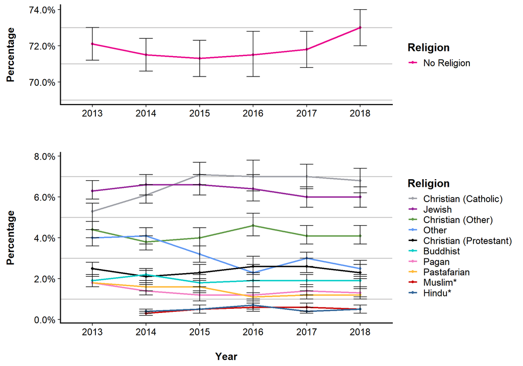

Error bars indicate the upper and lower bounds of the 95% confidence intervals.

* "Muslim" and "Hindu" were first added as options in the 2014 online survey, which may have resulted in differences between 2013 responses and 2014-17 responses.

|  | 2013 Percent | 2013 MoE +/- % |  | 2014 Percent | 2014 MoE +/- % |  | 2015 Percent | 2015 MoE +/- % |  | 2016 Percent | 2016 MoE +/- % |  | 2017 Percent | 2017 MoE +/- % |  | 2018 Percent | 2018 MoE +/- % |
| --- | --- | --- | --- | --- | --- | --- | --- | --- | --- | --- | --- | --- | --- | --- | --- | --- | --- |
| No Religion | 72.1 | 1.0 |  | 71.5 | 1.0 |  | 71.3 | 1.0 |  | 71.5 | 1.2 |  | 71.8 | 1.0 |  | 73.0 | 1.0 |
| Christian (Catholic) | 5.3 | 0.4 |  | 6.1 | 0.4 |  | 7.1 | 0.6 |  | 7.0 | 0.8 |  | 7.0 | 0.6 |  | 6.8 | 0.6 |
| Jewish | 6.3 | 0.4 |  | 6.6 | 0.6 |  | 6.6 | 0.6 |  | 6.4 | 0.6 |  | 6.0 | 0.6 |  | 6.0 | 0.6 |
| Christian (Other) | 4.4 | 0.4 |  | 3.8 | 0.4 |  | 4.0 | 0.4 |  | 4.6 | 0.6 |  | 4.1 | 0.4 |  | 4.1 | 0.4 |
| Other | 4.0 | 0.4 |  | 4.1 | 0.4 |  | 3.2 | 0.4 |  | 2.3 | 0.4 |  | 3.0 | 0.4 |  | 2.5 | 0.4 |
| Christian (Protestant) | 2.5 | 0.4 |  | 2.1 | 0.2 |  | 2.3 | 0.4 |  | 2.6 | 0.4 |  | 2.6 | 0.4 |  | 2.3 | 0.4 |
| Buddhist | 1.9 | 0.2 |  | 2.2 | 0.4 |  | 1.8 | 0.4 |  | 1.9 | 0.4 |  | 1.9 | 0.4 |  | 1.9 | 0.4 |
| Pagan | 1.8 | 0.2 |  | 1.4 | 0.2 |  | 1.2 | 0.2 |  | 1.2 | 0.4 |  | 1.4 | 0.2 |  | 1.3 | 0.2 |
| Pastafarian | 1.8 | 0.2 |  | 1.6 | 0.2 |  | 1.6 | 0.2 |  | 1.1 | 0.2 |  | 1.2 | 0.2 |  | 1.2 | 0.2 |
| Muslim* | NA | NA |  | 0.3 | 0.2 |  | 0.5 | 0.2 |  | 0.6 | 0.2 |  | 0.6 | 0.2 |  | 0.5 | 0.2 |
| Hindu* | NA | NA |  | 0.4 | 0.2 |  | 0.5 | 0.2 |  | 0.7 | 0.2 |  | 0.4 | 0.2 |  | 0.5 | 0.2 |

**Next:** Sociodemographic Characteristics: Gender Identities, Sexuality, Relationships